# Money Raised by Industry

Is the average amount of money raised different between industries?

2/27/2021

## Introduction

```r
#importing Start-up Investments Crunchbase data set.
#Source: https://www.kaggle.com/arindam235/startup-investments-crunchbase

investments <- readRDS("..\\Datasets\\kaggle_data_cleaned.rds")

allMarkets <- investments[c("market", "funding_total_usd", "funding_rounds")]
dim(allMarkets)
```

```
## [1] 18926     3
```

```r
markets <- c("Travel", "Transportation", "Games", "Music", "Video", "Finance", "Cloud Computing", "Health Care", "Hospitality", "Education")

#filtered to columns of interest, markets of interest, and remove all null funding amounts
d <- droplevels(allMarkets[which(allMarkets$market %in% markets), ])
summary(d)
```

```
##          market    funding_total_usd   funding_rounds
##  Health Care:631   Min.   :1.000e+02   Min.   : 1.000
##  Games      :387   1st Qu.:5.688e+05   1st Qu.: 1.000
##  Finance    :316   Median :3.250e+06   Median : 2.000
##  Education  :315   Mean   :1.946e+07   Mean   : 2.245
##  Hospitality:142   3rd Qu.:1.576e+07   3rd Qu.: 3.000
##  Music      :101   Max.   :1.507e+09   Max.   :13.000
##  (Other)    :292
```

For this analysis we will be comparing the the average amount of money raised in the following industries: Travel Transportation Games Music Video Finance Cloud Computing Health Care Hospitality Education

We chose these industries because it gives a broad range of comparison and we are curious to see if the total amount raised by start-ups in these industries differs, and if so, we wish to explore how they differ. For this analysis I will be performing an ANOVA F-Test to check for $\alpha = 0.05$, if the industries differ. To use the ANOVA F-Test we must first verify that the sample we are using satisfies the three conditions of normality, independence, and equal variance. Since it is likely the variance of funds differs drastically, we will be looking at the log of the total funding.

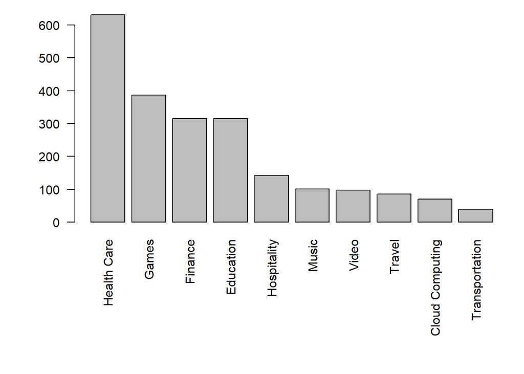

```r
#frequency of companies across markets in descending order
sorted_markets <- sort(table(d$market), decreasing=TRUE)
markets <- names(sorted_markets[1:10])
par(mar=c(10, 5, 1, 1)) #adjusting margins
barplot(sorted_markets, las=2, axisnames = T)
```

## Verifying Assumptions

### 1. Normality

```r
#Find the sample size for each market
for (market in markets) {
  cat(market, "sample size: ", dim(d[d$market == market, ])[1], "\n")
}
```

```
## Health Care sample size:  631
## Games sample size:  387
## Finance sample size:  316
## Education sample size:  315
## Hospitality sample size:  142
## Music sample size:  101
## Video sample size:  98
## Travel sample size:  85
## Cloud Computing sample size:  70
## Transportation sample size:  39
```

Given that the sample sizes range from a minimum of 39 (Transportation) to a maximum of 631 (Health Care), we can assume that the Central Limit Theorem will apply and that the means of the samples will follow a normal distribution.

### 2. Independence

Assuming independence of samples for this case. We have no further information on the data collection methods to confirm independence.That being said no two groups consists of the same company appearing in multiple markets and all companies are expected to be independent startups with no collaboration or affiliation with each other.

### 3. Equal Variance

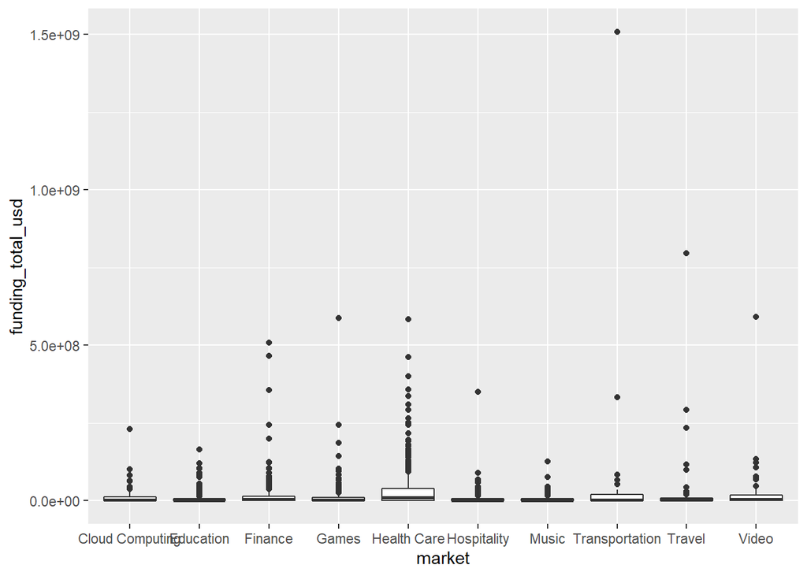

```r
#checking for equal variance
boxplot <- ggplot(d, aes(x = market, y = funding_total_usd))
boxplot + geom_boxplot()
```

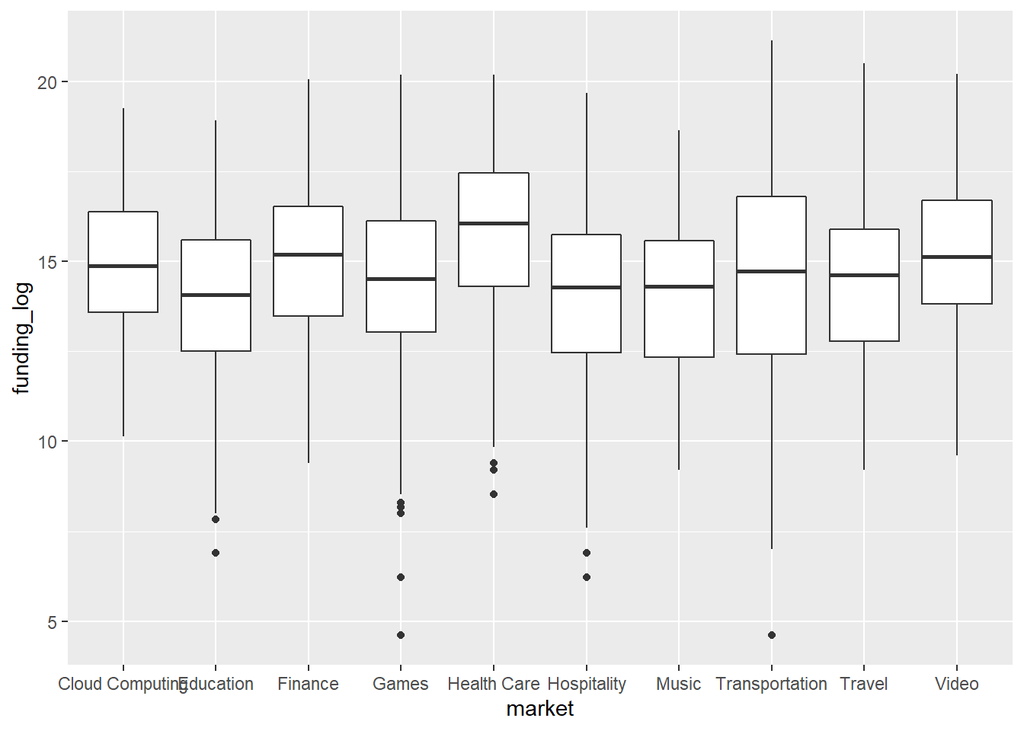

```r
#checking for equal vriance after the log transform
d$funding_log <- log(d$funding_total_usd)
log_boxplot <- ggplot(d, aes(x = market, y = funding_log))
log_boxplot + geom_boxplot()
```

## Performing Analysis

```r
summary(aov(funding_log ~ market, data=d))
```

```
##               Df Sum Sq Mean Sq F value Pr(>F)
## market         9   1063  118.15   22.63 <2e-16 ***
## Residuals   2174  11349    5.22
## ---
## Signif. codes:  0 '***' 0.001 '**' 0.01 '*' 0.05 '.' 0.1 ' ' 1
```

Using an ANOVA F-Test with $\alpha = 0.05$, we find evidence to reject the null hypothesis, and conclude that there is a difference in the funding total between the industries of interest.

### Visualising Differences

```r
#Plot the average funding amounts for each market
funding_means <- aggregate(funding_total_usd ~ market, data=d, FUN=mean)
funding_means$market <- with(funding_means, reorder(market, funding_total_usd))
print(funding_means)
```

```
##             market funding_total_usd
## 1  Cloud Computing          15455143
## 2        Education           7477842
## 3          Finance          17807273
## 4            Games          11482211
## 5      Health Care          32523567
## 6      Hospitality          10443607
## 7            Music           8034439
## 8   Transportation          57943721
## 9           Travel          23056698
## 10           Video          19939987
```

```r
print(with(funding_means,c(max(funding_total_usd) - mean(funding_total_usd), max(funding_total_usd) / mean(funding_total_usd))))
```

```
## [1] 3.752727e+07 2.838090e+00
```

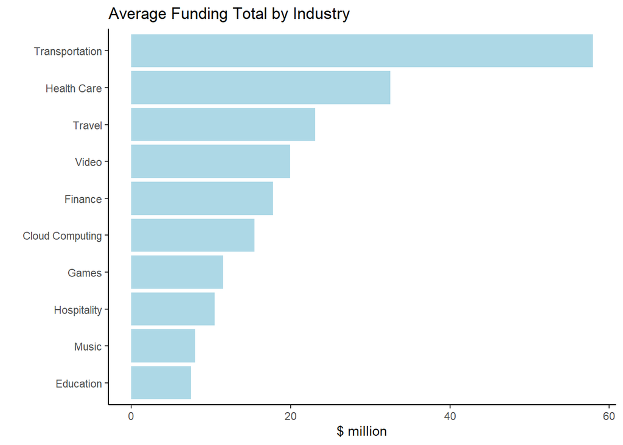

```r
ggplot(funding_means, aes(x = market, y = funding_total_usd/1000000)) + geom_bar(stat="identity", fill="lightblue") + coord_flip() + labs(title = "Average Funding Total by Industry", x = "", y = "$ million") + theme(panel.grid.major = element_blank(), panel.grid.minor = element_blank(),
panel.background = element_blank(), axis.line = element_line(colour = "black"))
```

### What do Funding Rounds look like?

```r
#plotting means of samples (for each category)
funding_rounds <- aggregate(funding_rounds ~ market, data=d, FUN=mean)
funding_rounds$market <- with(funding_rounds, reorder(market, funding_rounds))
print(funding_rounds)
```

```
##             market funding_rounds
## 1  Cloud Computing       2.271429
## 2        Education       1.898413
## 3          Finance       2.180380
## 4            Games       1.979328
## 5      Health Care       2.755943
## 6      Hospitality       1.654930
## 7            Music       2.029703
## 8   Transportation       2.461538
## 9           Travel       2.047059
## 10           Video       2.479592
```

```r
print(with(funding_rounds,c(max(funding_rounds) - mean(funding_rounds), max(funding_rounds) / mean(funding_rounds))))
```

```
## [1] 0.5801116 1.2666160
```

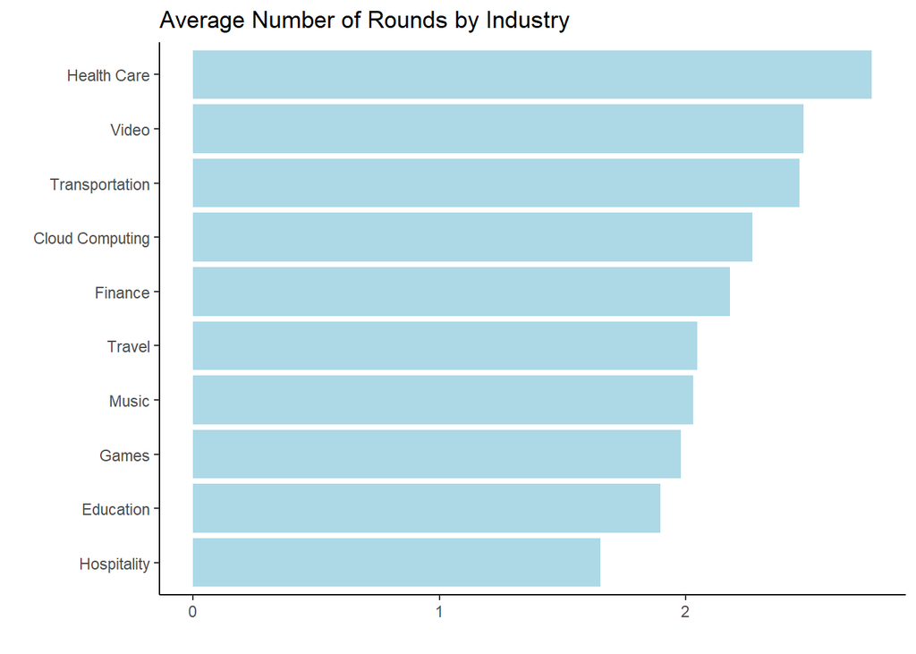

```r
#Plot the average funding amounts for each market
ggplot(funding_rounds, aes(x = market, y = funding_rounds)) + geom_bar(stat="identity", fill="lightblue") + coord_flip() + labs(title = "Average Number of Rounds by Industry", x = "", y = "") + theme(panel.grid.major = element_blank(), panel.grid.minor = element_blank(),
panel.background = element_blank(), axis.line = element_line(colour = "black"))
```

Checking assumption of equal variance:

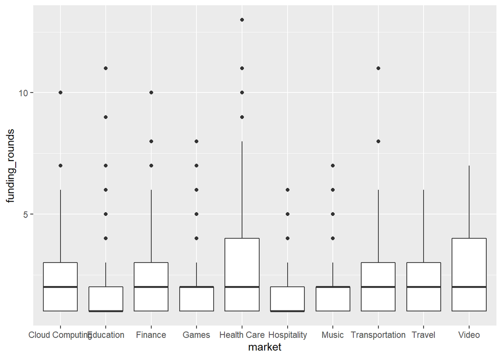

```r
boxplot <- ggplot(d, aes(x = market, y = funding_rounds))
boxplot + geom_boxplot()
```

Performing ANOVA F-Test:

```r
summary(aov(funding_rounds ~ market, data=d))
```

```
##               Df Sum Sq Mean Sq F value Pr(>F)
## market         9    296   32.88   12.91 <2e-16 ***
## Residuals   2174   5537    2.55
## ---
## Signif. codes:  0 '***' 0.001 '**' 0.01 '*' 0.05 '.' 0.1 ' ' 1
```

```r
#plotting means of samples (for each category)
funding_per_round <- d$funding_total_usd / d$funding_rounds
funding_per_round <- aggregate(funding_per_round ~ market, data=d, FUN=mean)
funding_per_round$market <- with(funding_per_round, reorder(market, funding_per_round))
print(funding_per_round)
```

```
##             market funding_per_round
## 1  Cloud Computing           4510027
## 2        Education           3759699
## 3          Finance           7455938
## 4            Games           4430513
## 5      Health Care          11608026
## 6      Hospitality           7415999
## 7            Music           2656108
## 8   Transportation          11847595
## 9           Travel           7889247
## 10           Video           7105604
```

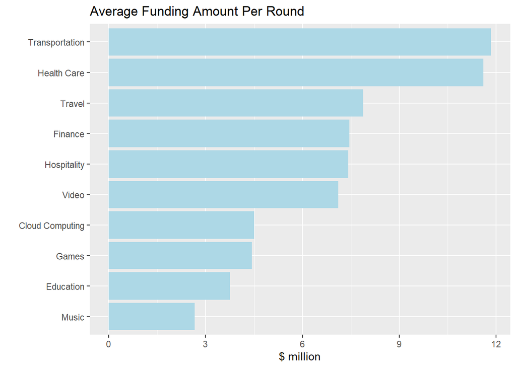

```r
#Plot the average funding amounts for each market
ggplot(funding_per_round, aes(x = market, y = funding_per_round/1000000)) + geom_bar(stat="identity", fill="lightblue") + coord_flip() + labs(title = "Average Funding Amount Per Round", x = "", y = "$ million")
```